# Churn Prediction

Dataset: https://www.kaggle.com/datasets/safrin03/predictive-analytics-for-customer-churn-dataset/data

About Dataset Context :

This dataset is part of a data science project focused on customer churn prediction for a subscription-based service. Customer churn, the rate at which customers cancel their subscriptions, is a vital metric for businesses offering subscription services. Predictive analytics techniques are employed to anticipate which customers are likely to churn, enabling companies to take proactive measures for customer retention.

Content :

This dataset contains anonymized information about customer subscriptions and their interaction with the service. The data includes various features such as subscription type, payment method, viewing preferences, customer support interactions, and other relevant attributes. It consists of three files such as "test.csv", "train.csv", "data_descriptions.csv".

Columns :

- *CustomerID*: Unique identifier for each customer
- *SubscriptionType*: Type of subscription plan chosen by the customer (e.g., Basic, Premium, Deluxe)
- *PaymentMethod*: Method used for payment (e.g., Credit Card, Electronic Check, PayPal)
- *PaperlessBilling*: Whether the customer uses paperless billing (Yes/No)
- *ContentType*: Type of content accessed by the customer (e.g., Movies, TV Shows, Documentaries)
- *MultiDeviceAccess*: Whether the customer has access on multiple devices (Yes/No)
- *DeviceRegistered*: Device registered by the customer (e.g., Smartphone, Smart TV, Laptop)
- *GenrePreference*: Genre preference of the customer (e.g., Action, Drama, Comedy)
- *Gender*: Gender of the customer (Male/Female)
- *ParentalControl*: Whether parental control is enabled (Yes/No)
- *SubtitlesEnabled*: Whether subtitles are enabled (Yes/No)
- *AccountAge*: Age of the customer's subscription account (in months)
- *MonthlyCharges*: Monthly subscription charges
- *TotalCharges*: Total charges incurred by the customer
- *ViewingHoursPerWeek*: Average number of viewing hours per week
- *SupportTicketsPerMonth*: Number of customer support tickets raised per month
- *AverageViewingDuration*: Average duration of each viewing session
- *ContentDownloadsPerMonth*: Number of content downloads per month
- *UserRating*: Customer satisfaction rating (1 to 5)
- *WatchlistSize*: Size of the customer's content watchlist

Acknowledgments : The dataset used in this project is obtained from Data Science Challenge on Coursera and is used for educational and research purposes. Any resemblance to real persons or entities is purely coincidental.

**The problem definition:**

The goal of this project is to build a predictive model that identifies customers who are likely to churn (i.e., stop using the service). Using historical customer data — including demographics, subscription details, and usage behavior — we aim to classify whether a customer will churn or remain active.

```python
import pandas as pd
import numpy as np

import matplotlib.pyplot as plt
import seaborn as sns
import plotly.express as px
import plotly.graph_objs as go
import plotly.figure_factory as ff
from plotly.subplots import make_subplots


from sklearn.compose import ColumnTransformer
from sklearn.preprocessing import StandardScaler, OneHotEncoder
from sklearn_pandas import DataFrameMapper

from sklearn.linear_model import LogisticRegression
from sklearn.neighbors import KNeighborsClassifier
from sklearn.tree import DecisionTreeClassifier
from sklearn.ensemble import RandomForestClassifier, GradientBoostingClassifier
from xgboost import XGBRFClassifier
from lightgbm import LGBMClassifier
from sklearn.model_selection import cross_validate
from sklearn.metrics import make_scorer,  recall_score, f1_score, roc_auc_score, classification_report, confusion_matrix

from sklearn.model_selection import StratifiedKFold
from sklearn.model_selection import train_test_split


from sklearn.pipeline import Pipeline
from sklearn.impute import SimpleImputer

from imblearn.over_sampling import SMOTE
from imblearn.pipeline import Pipeline

from datetime import datetime, timedelta
```

```python
df_test=pd.read_csv('test.csv')
df_train=pd.read_csv('train.csv')
```

# EDA and preprocessing

```python
df_train.head()
```

|  | AccountAge | MonthlyCharges | TotalCharges | SubscriptionType | PaymentMethod | PaperlessBilling | ContentType | MultiDeviceAccess | DeviceRegistered | ViewingHoursPerWeek | ... | ContentDownloadsPerMonth | GenrePreference | UserRating | SupportTicketsPerMonth | Gender | WatchlistSize | ParentalControl | SubtitlesEnabled | CustomerID | Churn |
| --- | --- | --- | --- | --- | --- | --- | --- | --- | --- | --- | --- | --- | --- | --- | --- | --- | --- | --- | --- | --- | --- |
| 0 | 20 | 11.055215 | 221.104302 | Premium | Mailed check | No | Both | No | Mobile | 36.758104 | ... | 10 | Sci-Fi | 2.176498 | 4 | Male | 3 | No | No | CB6SXPNVZA | 0 |
| 1 | 57 | 5.175208 | 294.986882 | Basic | Credit card | Yes | Movies | No | Tablet | 32.450568 | ... | 18 | Action | 3.478632 | 8 | Male | 23 | No | Yes | S7R2G87O09 | 0 |
| 2 | 73 | 12.106657 | 883.785952 | Basic | Mailed check | Yes | Movies | No | Computer | 7.395160 | ... | 23 | Fantasy | 4.238824 | 6 | Male | 1 | Yes | Yes | EASDC20BDT | 0 |
| 3 | 32 | 7.263743 | 232.439774 | Basic | Electronic check | No | TV Shows | No | Tablet | 27.960389 | ... | 30 | Drama | 4.276013 | 2 | Male | 24 | Yes | Yes | NPF69NT69N | 0 |
| 4 | 57 | 16.953078 | 966.325422 | Premium | Electronic check | Yes | TV Shows | No | TV | 20.083397 | ... | 20 | Comedy | 3.616170 | 4 | Female | 0 | No | No | 4LGYPK7VOL | 0 |

5 rows × 21 columns

```python
df_test.head()
```

|  | AccountAge | MonthlyCharges | TotalCharges | SubscriptionType | PaymentMethod | PaperlessBilling | ContentType | MultiDeviceAccess | DeviceRegistered | ViewingHoursPerWeek | AverageViewingDuration | ContentDownloadsPerMonth | GenrePreference | UserRating | SupportTicketsPerMonth | Gender | WatchlistSize | ParentalControl | SubtitlesEnabled | CustomerID |
| --- | --- | --- | --- | --- | --- | --- | --- | --- | --- | --- | --- | --- | --- | --- | --- | --- | --- | --- | --- | --- |
| 0 | 38 | 17.869374 | 679.036195 | Premium | Mailed check | No | TV Shows | No | TV | 29.126308 | 122.274031 | 42 | Comedy | 3.522724 | 2 | Male | 23 | No | No | O1W6BHP6RM |
| 1 | 77 | 9.912854 | 763.289768 | Basic | Electronic check | Yes | TV Shows | No | TV | 36.873729 | 57.093319 | 43 | Action | 2.021545 | 2 | Female | 22 | Yes | No | LFR4X92X8H |
| 2 | 5 | 15.019011 | 75.095057 | Standard | Bank transfer | No | TV Shows | Yes | Computer | 7.601729 | 140.414001 | 14 | Sci-Fi | 4.806126 | 2 | Female | 22 | No | Yes | QM5GBIYODA |
| 3 | 88 | 15.357406 | 1351.451692 | Standard | Electronic check | No | Both | Yes | Tablet | 35.586430 | 177.002419 | 14 | Comedy | 4.943900 | 0 | Female | 23 | Yes | Yes | D9RXTK2K9F |
| 4 | 91 | 12.406033 | 1128.949004 | Standard | Credit card | Yes | TV Shows | Yes | Tablet | 23.503651 | 70.308376 | 6 | Drama | 2.846880 | 6 | Female | 0 | No | No | ENTCCHR1LR |

```python
df_train.columns
```

```
Index(['AccountAge', 'MonthlyCharges', 'TotalCharges', 'SubscriptionType',
       'PaymentMethod', 'PaperlessBilling', 'ContentType', 'MultiDeviceAccess',
       'DeviceRegistered', 'ViewingHoursPerWeek', 'AverageViewingDuration',
       'ContentDownloadsPerMonth', 'GenrePreference', 'UserRating',
       'SupportTicketsPerMonth', 'Gender', 'WatchlistSize', 'ParentalControl',
       'SubtitlesEnabled', 'CustomerID', 'Churn'],
      dtype='object')
```

```python
df_test.columns
```

```
Index(['AccountAge', 'MonthlyCharges', 'TotalCharges', 'SubscriptionType',
       'PaymentMethod', 'PaperlessBilling', 'ContentType', 'MultiDeviceAccess',
       'DeviceRegistered', 'ViewingHoursPerWeek', 'AverageViewingDuration',
       'ContentDownloadsPerMonth', 'GenrePreference', 'UserRating',
       'SupportTicketsPerMonth', 'Gender', 'WatchlistSize', 'ParentalControl',
       'SubtitlesEnabled', 'CustomerID'],
      dtype='object')
```

```python
(df_train.shape, df_test.shape)
```

```
((243787, 21), (104480, 20))
```

```python
df_train.info()
```

```
<class 'pandas.core.frame.DataFrame'>
RangeIndex: 243787 entries, 0 to 243786
Data columns (total 21 columns):
 #   Column                    Non-Null Count   Dtype
---  ------                    --------------   -----
 0   AccountAge                243787 non-null  int64
 1   MonthlyCharges            243787 non-null  float64
 2   TotalCharges              243787 non-null  float64
 3   SubscriptionType          243787 non-null  object
 4   PaymentMethod             243787 non-null  object
 5   PaperlessBilling          243787 non-null  object
 6   ContentType               243787 non-null  object
 7   MultiDeviceAccess         243787 non-null  object
 8   DeviceRegistered          243787 non-null  object
 9   ViewingHoursPerWeek       243787 non-null  float64
 10  AverageViewingDuration    243787 non-null  float64
 11  ContentDownloadsPerMonth  243787 non-null  int64
 12  GenrePreference           243787 non-null  object
 13  UserRating                243787 non-null  float64
 14  SupportTicketsPerMonth    243787 non-null  int64
 15  Gender                    243787 non-null  object
 16  WatchlistSize             243787 non-null  int64
 17  ParentalControl           243787 non-null  object
 18  SubtitlesEnabled          243787 non-null  object
 19  CustomerID                243787 non-null  object
 20  Churn                     243787 non-null  int64
dtypes: float64(5), int64(5), object(11)
memory usage: 39.1+ MB
```

```python
df_test.info()
```

```
<class 'pandas.core.frame.DataFrame'>
RangeIndex: 104480 entries, 0 to 104479
Data columns (total 20 columns):
 #   Column                    Non-Null Count   Dtype
---  ------                    --------------   -----
 0   AccountAge                104480 non-null  int64
 1   MonthlyCharges            104480 non-null  float64
 2   TotalCharges              104480 non-null  float64
 3   SubscriptionType          104480 non-null  object
 4   PaymentMethod             104480 non-null  object
 5   PaperlessBilling          104480 non-null  object
 6   ContentType               104480 non-null  object
 7   MultiDeviceAccess         104480 non-null  object
 8   DeviceRegistered          104480 non-null  object
 9   ViewingHoursPerWeek       104480 non-null  float64
 10  AverageViewingDuration    104480 non-null  float64
 11  ContentDownloadsPerMonth  104480 non-null  int64
 12  GenrePreference           104480 non-null  object
 13  UserRating                104480 non-null  float64
 14  SupportTicketsPerMonth    104480 non-null  int64
 15  Gender                    104480 non-null  object
 16  WatchlistSize             104480 non-null  int64
 17  ParentalControl           104480 non-null  object
 18  SubtitlesEnabled          104480 non-null  object
 19  CustomerID                104480 non-null  object
dtypes: float64(5), int64(4), object(11)
memory usage: 15.9+ MB
```

```python
# there are no missing values
df_train.isnull().sum()
```

```
AccountAge                  0
MonthlyCharges              0
TotalCharges                0
SubscriptionType            0
PaymentMethod               0
PaperlessBilling            0
ContentType                 0
MultiDeviceAccess           0
DeviceRegistered            0
ViewingHoursPerWeek         0
AverageViewingDuration      0
ContentDownloadsPerMonth    0
GenrePreference             0
UserRating                  0
SupportTicketsPerMonth      0
Gender                      0
WatchlistSize               0
ParentalControl             0
SubtitlesEnabled            0
CustomerID                  0
Churn                       0
dtype: int64
```

```python
df_test.isnull().sum()
```

```
AccountAge                  0
MonthlyCharges              0
TotalCharges                0
SubscriptionType            0
PaymentMethod               0
PaperlessBilling            0
ContentType                 0
MultiDeviceAccess           0
DeviceRegistered            0
ViewingHoursPerWeek         0
AverageViewingDuration      0
ContentDownloadsPerMonth    0
GenrePreference             0
UserRating                  0
SupportTicketsPerMonth      0
Gender                      0
WatchlistSize               0
ParentalControl             0
SubtitlesEnabled            0
CustomerID                  0
dtype: int64
```

```python
# check class balance
df_train.groupby('Churn').CustomerID.nunique()
```

```
Churn
0    199605
1     44182
Name: CustomerID, dtype: int64
```

Classes are unbalanced.

The strategy of metrics: Do not use accuracy, but F1-score (only for Class 1), ROC-AUC

Balancing classes: Undersampling (delete the "zero" part of the users), oversampling (duplicate "units" or use SMOTE), or use models that take into account class weights (ex LogisticRegression)

```python
numeric_col=[]
for col  in df_train.columns:
    if(df_train[col].dtypes in ('float64','int64')):
        numeric_col.append(col)
print(f"Count of numeric columns in the datset - {len(numeric_col)}")
print(numeric_col)

numeric_col.remove('Churn')
```

```
Count of numeric columns in the datset - 10
['AccountAge', 'MonthlyCharges', 'TotalCharges', 'ViewingHoursPerWeek', 'AverageViewingDuration', 'ContentDownloadsPerMonth', 'UserRating', 'SupportTicketsPerMonth', 'WatchlistSize', 'Churn']
```

```python
#Find categorical  Columns
categorial_col=[]
for col  in df_train.columns:
    if(df_train[col].dtypes=='object'):
        categorial_col.append(col)
print(f"Count of categorical columns in the datset - {len(categorial_col)}")
print(categorial_col)
```

```
Count of categorical columns in the datset - 11
['SubscriptionType', 'PaymentMethod', 'PaperlessBilling', 'ContentType', 'MultiDeviceAccess', 'DeviceRegistered', 'GenrePreference', 'Gender', 'ParentalControl', 'SubtitlesEnabled', 'CustomerID']
```

```python
del df_train['CustomerID']
del df_test['CustomerID']
```

### Numeric Features Vizualization

```python
def plot_feature_distribution(df, feature: str, title_feature: str = None, nbins: int = 60):

    if title_feature is None:
        title_feature = feature

    fig = make_subplots(
        rows=2, cols=1,
        subplot_titles=(f"Distribution of {title_feature} by Churn",
                        f"Boxplot: {title_feature} by Churn"),
        shared_xaxes=False
    )

    hist_data = px.histogram(
        df,
        x=feature,
        color="Churn",
        barmode="stack",
        nbins=nbins,
        opacity=0.7
    )

    for trace in hist_data.data:
        trace.showlegend = True
        fig.add_trace(trace, row=1, col=1)

    box_data = px.box(
        df,
        x="Churn",
        y=feature,
        color="Churn"
    )

    for trace in box_data.data:
        trace.showlegend = False
        fig.add_trace(trace, row=2, col=1)

    fig.update_layout(
        height=800,
        showlegend=True,
        legend_title="Churn",
        xaxis=dict(title=title_feature),
        xaxis2=dict(title="Churn"),
        yaxis=dict(title="Count Clients"),
        yaxis2=dict(title=title_feature),
        title_text=f"{title_feature} vs Churn — Histogram & Boxplot"
    )

    fig.show()
```

```python
for col in numeric_col:
    print(col)
    print(df_train.groupby('Churn')[col].describe())
    plot_feature_distribution(df_train, feature=col, title_feature=col)
```

```
AccountAge
          count       mean        std  min   25%   50%   75%    max
Churn
0      199605.0  63.273290  33.953685  1.0  35.0  65.0  93.0  119.0
1       44182.0  45.674121  32.001262  1.0  18.0  40.0  69.0  119.0
```

```
MonthlyCharges
          count       mean       std       min       25%        50%  \
Churn
0      199605.0  12.286129  4.317675  4.990062  8.532456  12.189954
1       44182.0  13.414880  4.251322  4.990112  9.963733  13.855745

             75%        max
Churn
0      15.993218  19.989957
1      17.132808  19.989741
```

```
TotalCharges
          count        mean         std       min         25%         50%  \
Churn
0      199605.0  780.402245  524.200292  4.999861  362.799813  684.445761
1       44182.0  616.737816  496.333924  4.991154  218.502198  488.927265

               75%          max
Churn
0      1124.699587  2378.723844
1       903.552235  2356.614662
```

```
ViewingHoursPerWeek
          count       mean        std       min        25%        50%  \
Churn
0      199605.0  21.182697  11.198072  1.000133  11.601957  21.545178
1       44182.0  17.427741  10.932147  1.000065   7.898715  16.079108

             75%        max
Churn
0      30.931229  39.999723
1      26.218169  39.997750
```

```
AverageViewingDuration
          count       mean        std       min        25%        50%  \
Churn
0      199605.0  95.754533  50.281449  5.000547  52.664521  97.505261
1       44182.0  76.494840  48.466716  5.002643  34.398096  69.772525

              75%         max
Churn
0      139.403329  179.999275
1      114.371954  179.991594
```

```
ContentDownloadsPerMonth
          count       mean        std  min   25%   50%   75%   max
Churn
0      199605.0  25.383853  14.358435  0.0  13.0  26.0  38.0  49.0
1       44182.0  20.526323  14.028993  0.0   8.0  19.0  32.0  49.0
```

```
UserRating
          count      mean       std       min       25%       50%       75%  \
Churn
0      199605.0  2.990688  1.155398  1.000039  1.986598  2.983423  3.989193
1       44182.0  3.057037  1.153083  1.000007  2.065083  3.084849  4.057920

            max
Churn
0      4.999982
1      4.999989
```

```
SupportTicketsPerMonth
          count      mean       std  min  25%  50%  75%  max
Churn
0      199605.0  4.390576  2.866237  0.0  2.0  4.0  7.0  9.0
1       44182.0  5.017451  2.844926  0.0  3.0  5.0  8.0  9.0
```

```
WatchlistSize
          count       mean       std  min  25%   50%   75%   max
Churn
0      199605.0  11.944941  7.197050  0.0  6.0  12.0  18.0  24.0
1       44182.0  12.350867  7.165535  0.0  6.0  13.0  19.0  24.0
```

So, we clearly see that:

- Churned Users tend to have lover values for Account Age, Total Charges, Content Downloads Per Month, Average Viewing Duration and Viewing Hours Per Week. These features are likely interrelated and potentially collinear.
- Churned users also submit more support tickets, which may indicate a higher level of dissatisfaction, confusion, or unresolved technical issues — possibly contributing to their decision to leave.
- Two features stand out as non-intuitive:
  - Monthly Charges are higher among churned users, which might suggest pricing sensitivity or billing-related friction. This relationship needs further analysis
  - Watchlist Size is also higher among churned users. A possible interpretation is that these users are interested in content but face e.g., technical issues, save items for later rather than watch them. A next step would be to explore the correlation between Watchlist Size and actual Viewing Time.

### Categorial Features Visualization

```python
def plot_pie_by_churn(df, category_col: str, title: str = None):

    if title is None:
        title = f"{category_col} Distribution by Churn"

    categories = df[category_col].dropna().unique().tolist()

    default_colors = px.colors.qualitative.Plotly
    color_map = {
        cat: default_colors[i % len(default_colors)]
        for i, cat in enumerate(categories)
    }

    fig = make_subplots(
        rows=1, cols=2,
        specs=[[{'type': 'domain'}, {'type': 'domain'}]],
        subplot_titles=[
            f"{category_col} (Churn = 0)",
            f"{category_col} (Churn = 1)"
        ]
    )

    pie_0 = px.pie(
        df[df['Churn'] == 0],
        names=category_col,
        hole=0.33,
        category_orders={category_col: categories},
        color=category_col,
        color_discrete_map=color_map
    )

    pie_1 = px.pie(
        df[df['Churn'] == 1],
        names=category_col,
        hole=0.33,
        category_orders={category_col: categories},
        color=category_col,
        color_discrete_map=color_map
    )

    for trace in pie_0.data:
        fig.add_trace(trace, row=1, col=1)

    for trace in pie_1.data:
        fig.add_trace(trace, row=1, col=2)

    fig.update_layout(
        title_text=title,
        legend_title=category_col,
        showlegend=True,
        height=500
    )

    fig.show()
```

```python
categorial_col=categorial_col[:-1]
```

```python
for col in categorial_col:
    plot_pie_by_churn(df_train, category_col=col, title=f"{col} by Churn Statuses")
```

There are fewer clear distinctions in the categorical features between churned and non-churned users. However, a few patterns can be tentatively noted:

- Churned users are more likely to have a Basic subscription, while non-churned users tend to subscribe to Premium plans, which may indicate a link between churn and perceived value or feature limitations.
- There are also minor differences in the distribution of Payment Methods, but these patterns are less pronounced and would require statistical testing to validate.

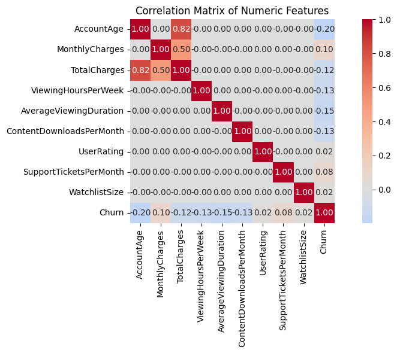

```python
numeric_df = df_train.select_dtypes(include="number")
corr = numeric_df.corr(numeric_only=True)

plt.figure(figsize=(10, 6))
sns.heatmap(corr, annot=True, fmt=".2f", cmap="coolwarm", center=0, square=True)
plt.title("Correlation Matrix of Numeric Features")
plt.tight_layout()
plt.show()
```

```python
from statsmodels.stats.outliers_influence import variance_inflation_factor
from sklearn.preprocessing import StandardScaler

features = [
    'AccountAge', 'MonthlyCharges', 'TotalCharges',
    'ViewingHoursPerWeek', 'AverageViewingDuration',
    'ContentDownloadsPerMonth', 'UserRating',
    'SupportTicketsPerMonth', 'WatchlistSize'
]

X = df_train[features].copy()

X_scaled = StandardScaler().fit_transform(X)

vif_df = pd.DataFrame()
vif_df['feature'] = features
vif_df['VIF'] = [variance_inflation_factor(X_scaled, i) for i in range(X_scaled.shape[1])]

print(vif_df)
```

```
                    feature        VIF
0                AccountAge   9.334092
1            MonthlyCharges   4.064473
2              TotalCharges  12.415762
3       ViewingHoursPerWeek   1.000029
4    AverageViewingDuration   1.000020
5  ContentDownloadsPerMonth   1.000026
6                UserRating   1.000019
7    SupportTicketsPerMonth   1.000007
8             WatchlistSize   1.000027
```

We see a high colinearity between AccountAge and TotalCharges. For linear models, we will remove the TotalCharges feature to avoid multicollinearity (this worsens the stability of the coefficients and confuses interpretation). Why TotalCharges? Usually, monetary metrics depend on many factors and are more difficult to interpret. For tree models (Decision Tree, Random Forest, XGBoost), you can leave both features. These models do not suffer from multicollenarity, they choose the desired feature themselves.

## Extra: one look at outlier detection methods

Let's take a short look at the methods of detecting outliers

### Boxplot / Visual Inspection

What it is - Visual method based on the IQR rule (Interquartile Range). Outliers are values outside the whiskers.

Pros:

- Quick and intuitive
- Highlights extreme values clearly

Cons:

- Only works for 1D (single feature at a time)
- Not scalable for high dimensions

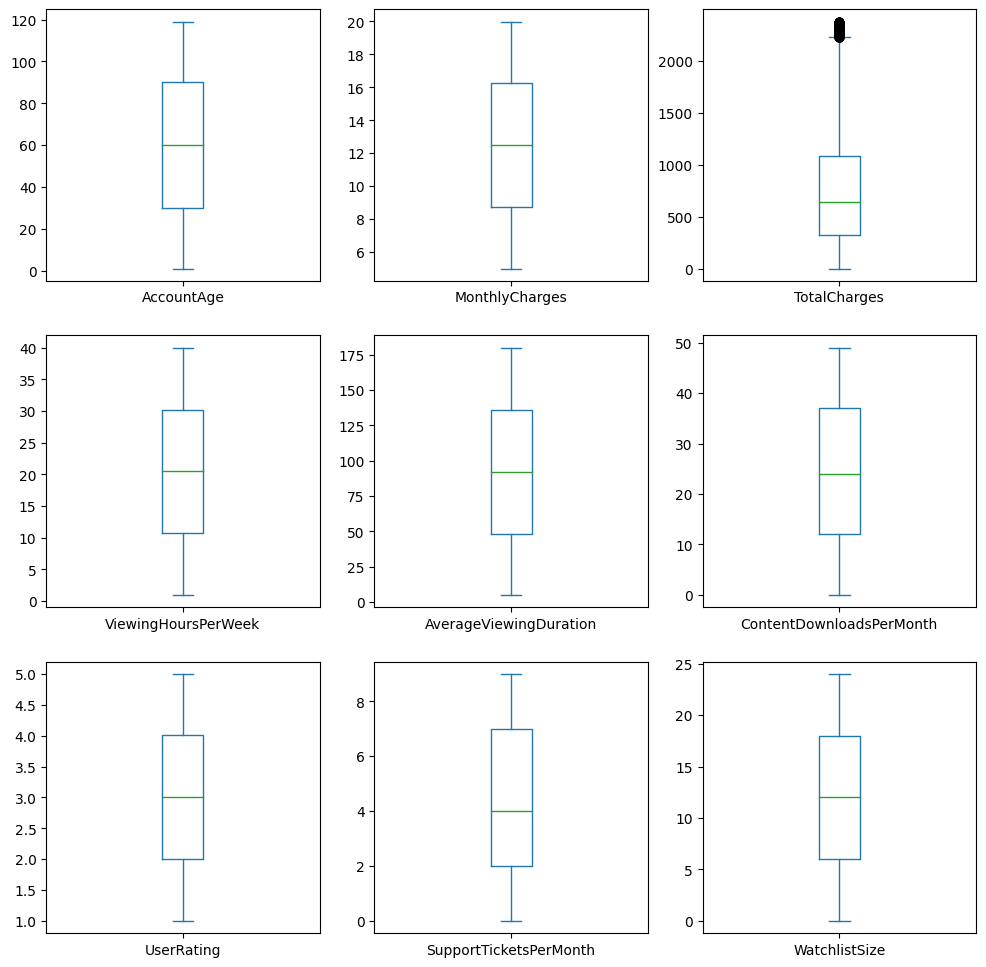

```python
X.plot(kind="box", subplots=True, figsize=(12, 12), layout=(3, 3))
plt.show()
```

### IQR

- defines outliers as values beyond 1.5×IQR from Q1/Q3.

Pros:

- Very easy to implement
- No assumptions about distribution

Cons:

- Ignores relationships between features
- Not useful for multivariate anomalies

```python
def count_iqr_outliers(df, threshold=1.5):

    numeric_cols = df[features]
    outlier_counts = {}

    for col in numeric_cols:
        Q1 = df[col].quantile(0.25)
        Q3 = df[col].quantile(0.75)
        IQR = Q3 - Q1

        lower = Q1 - threshold * IQR
        upper = Q3 + threshold * IQR

        outliers = (df[col] < lower) | (df[col] > upper)
        outlier_counts[col] = outliers.sum()

    return pd.Series(outlier_counts).sort_values(ascending=False)
```

```python
outliers_dict = count_iqr_outliers(df_train)
outliers_dict
```

```
TotalCharges                741
AccountAge                    0
MonthlyCharges                0
ViewingHoursPerWeek           0
AverageViewingDuration        0
ContentDownloadsPerMonth      0
UserRating                    0
SupportTicketsPerMonth        0
WatchlistSize                 0
dtype: int64
```

### LocalOutlierFactor (LOF)

Density-based algorithm. Compares local density of a point to its neighbors.

Pros:

- Captures local anomalies
- No need to label data (unsupervised)

Cons:

- Sensitive to n_neighbors parameter
- It learns and evaluates only those points that were immediately given to it.

```python
from sklearn.neighbors import KNeighborsClassifier, LocalOutlierFactor
```

```python
lof = LocalOutlierFactor(n_neighbors=20)

lof.fit_predict(df_train[numeric_col])
```

```
array([1, 1, 1, ..., 1, 1, 1])
```

```
[-1.32858604 -1.286969   -1.26622162 -1.2656214  -1.24939208 -1.24444974]
```

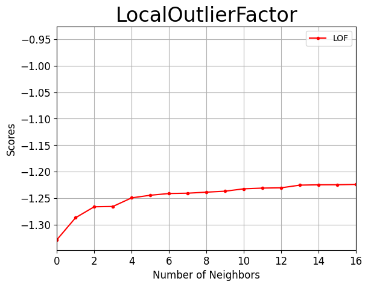

```python
df_scores = lof.negative_outlier_factor_
print(np.sort(df_scores)[0:6])

scores = pd.DataFrame(np.sort(df_scores))
plt.figure(figsize=(14, 10))
scores.plot(stacked=True, xlim=[0, 16], style=".-", color="red")
plt.title("LocalOutlierFactor", fontsize=24)
plt.xlabel("Number of Neighbors", fontsize=12)
plt.ylabel("Scores", fontsize=12)
plt.xticks(fontsize=12)
plt.yticks(fontsize=12)
plt.grid()
plt.legend(["LOF"])
plt.show()
```

### Isolation Forest

Tree-based algorithm that "isolates" anomalies quickly by random splits.

Pros:

- Scalable and fast
- Works with mixed data
- Can be used on new/unseen data

Cons:

- Can be unstable with small datasets
- Randomness requires tuning / multiple runs

```python
from sklearn.ensemble import IsolationForest

iso = IsolationForest(contamination=0.05, random_state=42)
df_train["iso_score"] = iso.fit_predict(df_train[features])
```

```python
outliers = df_train[df_train["iso_score"] == -1]
inliers = df_train[df_train["iso_score"] == 1]

for col in numeric_col:
    print(f"{col}: outliers mean={outliers[col].mean():.2f}, inliers mean={inliers[col].mean():.2f}")
```

```
AccountAge: outliers mean=67.70, inliers mean=59.68
MonthlyCharges: outliers mean=14.99, inliers mean=12.36
TotalCharges: outliers mean=1098.50, inliers mean=732.44
ViewingHoursPerWeek: outliers mean=19.78, inliers mean=20.54
AverageViewingDuration: outliers mean=89.47, inliers mean=92.41
ContentDownloadsPerMonth: outliers mean=25.40, inliers mean=24.46
UserRating: outliers mean=3.26, inliers mean=2.99
SupportTicketsPerMonth: outliers mean=4.36, inliers mean=4.51
WatchlistSize: outliers mean=11.08, inliers mean=12.07
```

```python
del df_train['iso_score']
```

# Feature Engineering

```python
X_train= df_train.drop(columns='Churn')
y_train=df_train['Churn']

X_test = df_test
```

We chose OneHotEncoder because it does not impose any artificial ordering between categories. Unlike LabelEncoder, which converts categories into integers (e.g., "Basic" → 0, "Standard" → 1, "Premium" → 2), OneHotEncoder treats each category as an independent binary feature. This avoids misleading the model into assuming a ranking where none exists — which is especially important for nominal variables such as subscription type, payment method, or content genre.

We selected StandardScaler because it standardizes features by removing the mean and scaling to unit variance, which is optimal for most linear models, SVMs, and PCA. Compared to MinMaxScaler, StandardScaler is less sensitive to the presence of extreme values (though not fully robust) and does not squash data into a fixed 0–1 range, preserving variance. We did not use RobustScaler because our numerical features do not contain significant outliers that would distort mean-based scaling.

```python
binary_cols = ['PaperlessBilling', 'MultiDeviceAccess', 'ParentalControl', 'SubtitlesEnabled']

for col in binary_cols:
    if X_train[col].dtype == 'object':
        X_train[col] = X_train[col].map({'Yes': 1, 'No': 0})
        X_test[col] = X_test[col].map({'Yes': 1, 'No': 0})

X_train['Gender'] = X_train['Gender'].map({'Female': 1, 'Male': 0})
X_test['Gender'] = X_test['Gender'].map({'Female': 1, 'Male': 0})


scaled_features = [
    'AccountAge', 'MonthlyCharges', 'TotalCharges',
    'ViewingHoursPerWeek', 'AverageViewingDuration',
    'ContentDownloadsPerMonth', 'UserRating',
    'SupportTicketsPerMonth', 'WatchlistSize'
]

one_hot_encoding_cols = ['SubscriptionType', 'PaymentMethod', 'ContentType', 'DeviceRegistered', 'GenrePreference']


all_cols = X_train.columns.tolist()

other_features = [col for col in all_cols if col not in scaled_features + one_hot_encoding_cols]

mapper = DataFrameMapper(

    [([col], [SimpleImputer(strategy='mean'), StandardScaler()]) for col in scaled_features] +
    [([col], [SimpleImputer(strategy='most_frequent'), OneHotEncoder(drop='first', sparse_output=False)]) for col in one_hot_encoding_cols] +
    [([col], None) for col in other_features],

    input_df=True, df_out=True
)

X_train_final = mapper.fit_transform(X_train)
X_test_final = mapper.transform(X_test)
```

# Models

```python
models = [
    ('LogReg', LogisticRegression(max_iter=1000)),
    ('KNN', KNeighborsClassifier()),
    ('DTClass', DecisionTreeClassifier()),
    ('RFClass', RandomForestClassifier()),
    ('GBM', GradientBoostingClassifier()),
    ("XGBoost", XGBRFClassifier()),
    ("LightGBM", LGBMClassifier())
]
```

```python
cv = StratifiedKFold(n_splits=5, shuffle=True, random_state=42)

scoring = {
    'recall': 'recall',
    'f1': 'f1',
    'roc_auc': 'roc_auc'
}

for name, model in models:
    acc = cross_validate(model, X_train_final, y_train, cv=cv, scoring=scoring)

    print(f"Model: {name}")
    print("Recall:", round(acc["test_recall"].mean(), 4))
    print("F1:", round(acc["test_f1"].mean(), 4))
    print("ROC AUC:", round(acc["test_roc_auc"].mean(), 4))
    print(f"\n")
```

```
Model: LogReg
Recall: 0.1184
F1: 0.1961
ROC AUC: 0.7501


Model: KNN
Recall: 0.1597
F1: 0.2242
ROC AUC: 0.6326


Model: DTClass
Recall: 0.2987
F1: 0.2823
ROC AUC: 0.5589


Model: RFClass
Recall: 0.0786
F1: 0.1381
ROC AUC: 0.728


Model: GBM
Recall: 0.0933
F1: 0.1608
ROC AUC: 0.7465


Model: XGBoost
Recall: 0.0964
F1: 0.1624
ROC AUC: 0.7255


[LightGBM] [Info] Number of positive: 35345, number of negative: 159684
[LightGBM] [Info] Auto-choosing row-wise multi-threading, the overhead of testing was 0.002302 seconds.
You can set `force_row_wise=true` to remove the overhead.
And if memory is not enough, you can set `force_col_wise=true`.
```

[output cut: 25 more lines]

[output not shown]

If you need a quality balance (F1 + AUC):

- LogisticRegression is the most balanced: F1 = 0.1961, ROC AUC = 0.75
- LightGBM and GBM are close in AUC, but Recall is lower.

## 1 - SMOTE

SMOTE (Synthetic Minority Oversampling Technique) is a smart way to "add" more than 1 without copying them, but creating new similar ones. It is used when it is necessary to improve recall or F1 in a minority class, especially when there is an imbalance.

```python
smote = SMOTE(random_state=42)
X_resampled, y_resampled = smote.fit_resample(X_train_final, y_train)
```

```python
smote = SMOTE(random_state=42)

cv = StratifiedKFold(n_splits=5, shuffle=True, random_state=42)

scoring = {
    'recall': 'recall',
    'f1': 'f1',
    'roc_auc': 'roc_auc'
            }

models = [
    ("LogReg", LogisticRegression(class_weight=None, max_iter=1000, random_state=42)),
    ("RandomForest", RandomForestClassifier(class_weight=None, n_estimators=100, random_state=42)),
    ("DecisionTree", DecisionTreeClassifier(class_weight=None, random_state=42))
]


for name, model in models:
    pipe = Pipeline([
        ('smote', smote),
        ('clf', model)
    ])

    acc = cross_validate(pipe, X_train_final, y_train, cv=cv, scoring=scoring)

    print(f"Model: {name}")
    print("Recall:", round(acc["test_recall"].mean(), 4))
    print("F1:", round(acc["test_f1"].mean(), 4))
    print("ROC AUC:", round(acc["test_roc_auc"].mean(), 4))
    print(f"\n")
```

```
Model: LogReg
Recall: 0.6487
F1: 0.4304
ROC AUC: 0.7364


Model: RandomForest
Recall: 0.2792
F1: 0.3373
ROC AUC: 0.7285


Model: DecisionTree
Recall: 0.3355
F1: 0.2906
ROC AUC: 0.56
```

## 2 - class_weight='balanced'

```python
cv = StratifiedKFold(n_splits=5, shuffle=True, random_state=42)
scoring = {
    'recall': 'recall',
    'f1': 'f1',
    'roc_auc': 'roc_auc'
}

models = [
    ("LogReg_balanced", LogisticRegression(class_weight='balanced', max_iter=1000, random_state=42)),
    ("RandomForest_balanced", RandomForestClassifier(class_weight='balanced', n_estimators=100, random_state=42)),
     ("DecisionTree_balanced", DecisionTreeClassifier(class_weight='balanced', random_state=42))

]

for name, model in models:
    acc = cross_validate(model, X_train_final, y_train, cv=cv, scoring=scoring)

    print(f"Model: {name}")
    print("Recall:", round(acc["test_recall"].mean(), 4))
    print("F1:", round(acc["test_f1"].mean(), 4))
    print("ROC AUC:", round(acc["test_roc_auc"].mean(), 4))
    print(f"\n")
```

```
Model: LogReg_balanced
Recall: 0.6922
F1: 0.4387
ROC AUC: 0.7501


Model: RandomForest_balanced
Recall: 0.0529
F1: 0.0969
ROC AUC: 0.7303


Model: DecisionTree_balanced
Recall: 0.2708
F1: 0.2724
ROC AUC: 0.556
```

```python
X_tr, X_val, y_tr, y_val = train_test_split(X_train_final, y_train, test_size=0.2, random_state=42, stratify=y_train)
```

```python
model = LogisticRegression(class_weight='balanced', max_iter=1000, random_state=42)
model.fit(X_tr, y_tr)


y_val_pred = model.predict(X_val)
y_val_proba = model.predict_proba(X_val)[:, 1]
```

```python
print("Classification Report:")
print(classification_report(y_val, y_val_pred, digits=4))


print("ROC AUC:", round(roc_auc_score(y_val, y_val_proba), 4))

print("Confusion Matrix:")
print(confusion_matrix(y_val, y_val_pred))
```

```
Classification Report:
              precision    recall  f1-score   support

           0     0.9105    0.6749    0.7752     39921
           1     0.3229    0.7004    0.4420      8837

    accuracy                         0.6795     48758
   macro avg     0.6167    0.6876    0.6086     48758
weighted avg     0.8040    0.6795    0.7148     48758

ROC AUC: 0.7545
Confusion Matrix:
[[26943 12978]
 [ 2648  6189]]
```

```python
threshold = 0.3
y_val_pred_custom = (y_val_proba >= threshold).astype(int)

print("Classification Report (threshold = 0.3):")
print(classification_report(y_val, y_val_pred_custom, digits=4))

print("ROC AUC:", round(roc_auc_score(y_val, y_val_pred_custom), 4))

print("Confusion Matrix:")
print(confusion_matrix(y_val, y_val_pred_custom))
```

```
Classification Report (threshold = 0.3):
              precision    recall  f1-score   support

           0     0.9521    0.3509    0.5128     39921
           1     0.2389    0.9203    0.3793      8837

    accuracy                         0.4541     48758
   macro avg     0.5955    0.6356    0.4461     48758
weighted avg     0.8229    0.4541    0.4886     48758

ROC AUC: 0.6356
Confusion Matrix:
[[14008 25913]
 [  704  8133]]
```

We experimented with lowering the classification threshold to 0.3 in order to capture more positive cases (churned customers). While this significantly increased recall (up to ~92%), it also caused a sharp drop in precision (down to ~24%) and overall accuracy.

This means that although we correctly identified almost all churners, the model also falsely labeled a very large number of non-churners as churners. In practical terms, this could lead to wasting resources on users who are not actually at risk, which may not be sustainable in a real-world scenario.

Therefore, a threshold of 0.3 does not provide a good balance between recall and precision, and we recommend sticking with the default threshold of 0.5 or finding an optimized value based on business constraints.

## Is Logistic Regression Suitable for Predicting Churn?

Technically, yes. Logistic regression is a valid choice for predicting whether a customer will churn (binary outcome: 1 or 0). However, in our case, we have more than just the churn indicator — we also know how long a customer stays before leaving.

This means we are dealing with two variables:

- A binary variable: whether the customer churned (1/0),
- A continuous variable: the time until churn.

Generalized Linear Models (GLM) GLM is a general modeling framework defined by the equation:

$$ g(\mathbb{E}[Y]) = \beta_0 + \beta_1 x_1 + \dots + \beta_p x_p $$

Here:

- Y - the target variable,
- 𝑔 - the link function,
- 𝛽 - are the model coefficients.

Time-to-Event Modeling and the Weibull Distribution When we model time until an event (like churn), we enter the domain of survival regression. A common choice for modeling such durations is the Weibull distribution.

The Weibull distribution is flexible and defined by two parameters:

- 𝛼 (scale) — controls the spread of the distribution,
- 𝜌 (shape) — controls the hazard behavior over time.

Different values of 𝜌 allow the distribution to model increasing, decreasing, or constant risk over time.

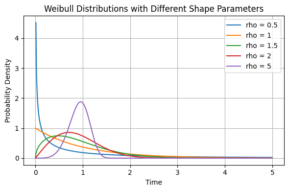

```python
from scipy.stats import weibull_min

x_weibull = np.linspace(0, 5, 500)
shapes = [0.5, 1, 1.5, 2, 5]
plt.figure(figsize=(6, 4))
for shape in shapes:
    y_weibull = weibull_min.pdf(x_weibull, c=shape)
    plt.plot(x_weibull, y_weibull, label=f"rho = {shape}")

plt.title("Weibull Distributions with Different Shape Parameters")
plt.xlabel("Time")
plt.ylabel("Probability Density")
plt.legend()
plt.grid(True)
plt.tight_layout()
plt.show()
```

```python
import lifelines as lf
```

```python
churn = df_train.loc[:, ['Churn', 'AccountAge', 'SubtitlesEnabled', 'ParentalControl',
                          'MonthlyCharges', 'PaperlessBilling',
                          'PaymentMethod','SubscriptionType',
                         'ViewingHoursPerWeek','UserRating',
                         'SupportTicketsPerMonth',
                         'ContentType', 'MultiDeviceAccess','DeviceRegistered',
                         'AverageViewingDuration', 'ContentDownloadsPerMonth',
                         'GenrePreference','WatchlistSize'
                ]]
```

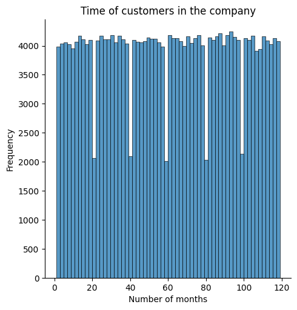

```python
sns.displot(churn.AccountAge, kde = False)
plt.xlabel('Number of months')
plt.ylabel('Frequency')
plt.title('Time of customers in the company')
```

```python
surv = lf.WeibullAFTFitter()

surv.fit(df = churn, duration_col = 'AccountAge', event_col = 'Churn', \
         formula = 'C(SubtitlesEnabled) + C(ParentalControl) + MonthlyCharges + C(PaperlessBilling)\
         +C(PaymentMethod) + C(SubscriptionType) + ViewingHoursPerWeek + UserRating + SupportTicketsPerMonth + \
         C(ContentType) + C(MultiDeviceAccess)+ C(DeviceRegistered)+\
            AverageViewingDuration + ContentDownloadsPerMonth + C(GenrePreference) + WatchlistSize')
```

```
<lifelines.WeibullAFTFitter: fitted with 243787 total observations, 199605 right-censored observations>
```

```python
surv.print_summary()
```

| model | lifelines.WeibullAFTFitter |
| --- | --- |
| duration col | 'AccountAge' |
| event col | 'Churn' |
| number of observations | 243787 |
| number of events observed | 44182 |
| log-likelihood | -292433.13 |
| time fit was run | 2025-07-25 11:32:29 UTC |

|  |  | coef | exp(coef) | se(coef) | coef lower 95% | coef upper 95% | exp(coef) lower 95% | exp(coef) upper 95% | cmp to | z | p | -log2(p) |
| --- | --- | --- | --- | --- | --- | --- | --- | --- | --- | --- | --- | --- |
| lambda_ | Intercept | 5.30 | 200.14 | 0.03 | 5.24 | 5.36 | 188.96 | 211.99 | 0.00 | 180.66 | <0.005 | inf |
|  | C(SubtitlesEnabled)[T.Yes] | 0.04 | 1.04 | 0.01 | 0.02 | 0.06 | 1.02 | 1.06 | 0.00 | 4.89 | <0.005 | 19.95 |
|  | C(ParentalControl)[T.Yes] | 0.02 | 1.02 | 0.01 | 0.01 | 0.04 | 1.01 | 1.04 | 0.00 | 2.59 | 0.01 | 6.70 |
|  | MonthlyCharges | -0.04 | 0.96 | 0.00 | -0.04 | -0.04 | 0.96 | 0.96 | 0.00 | -43.33 | <0.005 | inf |
|  | C(PaperlessBilling)[T.Yes] | 0.00 | 1.00 | 0.01 | -0.01 | 0.02 | 0.99 | 1.02 | 0.00 | 0.42 | 0.68 | 0.57 |
|  | C(PaymentMethod)[T.Credit card] | 0.09 | 1.09 | 0.01 | 0.06 | 0.11 | 1.07 | 1.12 | 0.00 | 7.19 | <0.005 | 40.52 |
|  | C(PaymentMethod)[T.Electronic check] | -0.05 | 0.95 | 0.01 | -0.08 | -0.03 | 0.93 | 0.97 | 0.00 | -4.56 | <0.005 | 17.58 |
|  | C(PaymentMethod)[T.Mailed check] | -0.05 | 0.95 | 0.01 | -0.07 | -0.03 | 0.93 | 0.97 | 0.00 | -4.48 | <0.005 | 17.06 |
|  | C(SubscriptionType)[T.Premium] | 0.16 | 1.17 | 0.01 | 0.14 | 0.18 | 1.15 | 1.19 | 0.00 | 15.26 | <0.005 | 172.23 |
|  | C(SubscriptionType)[T.Standard] | 0.05 | 1.05 | 0.01 | 0.03 | 0.07 | 1.03 | 1.07 | 0.00 | 4.95 | <0.005 | 20.33 |
|  | ViewingHoursPerWeek | 0.02 | 1.02 | 0.00 | 0.02 | 0.02 | 1.02 | 1.02 | 0.00 | 54.84 | <0.005 | inf |
|  | UserRating | -0.03 | 0.97 | 0.00 | -0.04 | -0.03 | 0.96 | 0.97 | 0.00 | -9.61 | <0.005 | 70.27 |
|  | SupportTicketsPerMonth | -0.06 | 0.95 | 0.00 | -0.06 | -0.05 | 0.94 | 0.95 | 0.00 | -37.42 | <0.005 | 1015.57 |
|  | C(ContentType)[T.Movies] | 0.06 | 1.06 | 0.01 | 0.04 | 0.08 | 1.04 | 1.08 | 0.00 | 5.69 | <0.005 | 26.25 |
|  | C(ContentType)[T.TV Shows] | 0.06 | 1.06 | 0.01 | 0.04 | 0.08 | 1.04 | 1.08 | 0.00 | 5.89 | <0.005 | 27.93 |
|  | C(MultiDeviceAccess)[T.Yes] | 0.01 | 1.01 | 0.01 | -0.01 | 0.02 | 0.99 | 1.02 | 0.00 | 1.01 | 0.31 | 1.68 |
|  | C(DeviceRegistered)[T.Mobile] | -0.01 | 0.99 | 0.01 | -0.03 | 0.01 | 0.97 | 1.01 | 0.00 | -0.75 | 0.45 | 1.14 |
|  | C(DeviceRegistered)[T.TV] | 0.01 | 1.01 | 0.01 | -0.02 | 0.03 | 0.98 | 1.03 | 0.00 | 0.49 | 0.63 | 0.68 |
|  | C(DeviceRegistered)[T.Tablet] | -0.01 | 0.99 | 0.01 | -0.03 | 0.01 | 0.97 | 1.02 | 0.00 | -0.68 | 0.49 | 1.02 |
|  | AverageViewingDuration | 0.01 | 1.01 | 0.00 | 0.01 | 0.01 | 1.01 | 1.01 | 0.00 | 62.84 | <0.005 | inf |
|  | ContentDownloadsPerMonth | 0.02 | 1.02 | 0.00 | 0.02 | 0.02 | 1.02 | 1.02 | 0.00 | 55.72 | <0.005 | inf |
|  | C(GenrePreference)[T.Comedy] | -0.13 | 0.88 | 0.01 | -0.15 | -0.10 | 0.86 | 0.90 | 0.00 | -9.68 | <0.005 | 71.26 |
|  | C(GenrePreference)[T.Drama] | -0.06 | 0.94 | 0.01 | -0.08 | -0.03 | 0.92 | 0.97 | 0.00 | -4.30 | <0.005 | 15.83 |
|  | C(GenrePreference)[T.Fantasy] | -0.05 | 0.95 | 0.01 | -0.07 | -0.02 | 0.93 | 0.98 | 0.00 | -3.51 | <0.005 | 11.13 |
|  | C(GenrePreference)[T.Sci-Fi] | -0.12 | 0.89 | 0.01 | -0.15 | -0.10 | 0.86 | 0.91 | 0.00 | -9.19 | <0.005 | 64.46 |
|  | WatchlistSize | -0.01 | 0.99 | 0.00 | -0.01 | -0.00 | 0.99 | 1.00 | 0.00 | -10.29 | <0.005 | 80.10 |
| rho_ | Intercept | 0.14 | 1.15 | 0.00 | 0.13 | 0.15 | 1.14 | 1.16 | 0.00 | 32.98 | <0.005 | 789.87 |

| Concordance | 0.66 |
| --- | --- |
| AIC | 584920.26 |
| log-likelihood ratio test | 15309.47 on 25 df |
| -log2(p) of ll-ratio test | inf |

```python
summary = surv.summary
```

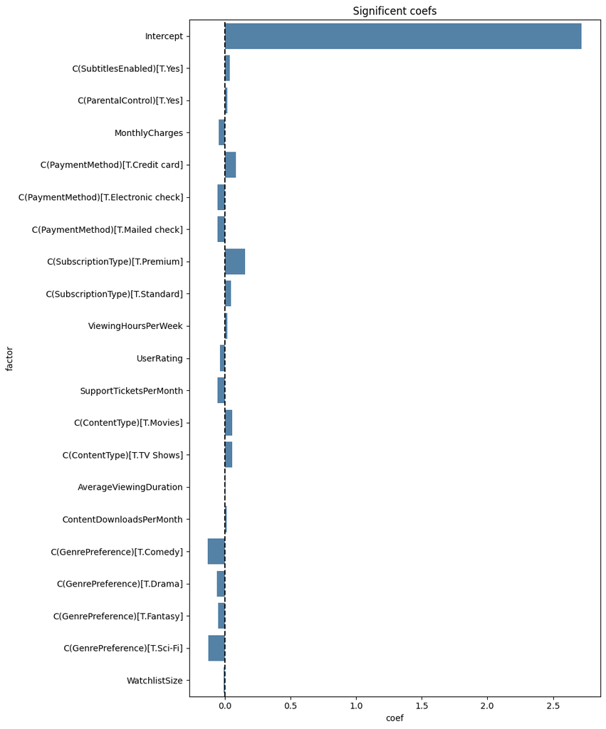

```python
summary = surv.summary.reset_index()
summary = summary[summary["p"] < 0.05]
plt.figure(figsize=(10, 12))
sns.barplot(
    data=summary,
    x="coef",
    y="covariate",
    color="steelblue",
    errorbar=None
)
plt.axvline(0, color="black", linestyle="--")
plt.title("Significent coefs")
plt.xlabel("coef")
plt.ylabel("factor")
plt.tight_layout()
plt.show()
```

Factors that increase account longevity :

- Premium Subscription -> Increases account lifetime by ~17%
- Credit Card Payment -> Associated with ~9% longer account life — possibly indicating more committed users
- Content Type TV Shows and Movies -> 6–8% longer lifetime
- Content Downloads per Month -> Slight but significant positive effect on retention.

Factors that shorten account lifetime:

- Support Tickets per Month (to ~5%)
- Genre Preferences (Comedy, Sci-Fi, Fantasy, Drama) -> negatively associated with account longevity (up to 12% shorter time)
- Monthly Charges -> Higher charges slightly increase churn risk.
- Watchlist Size: -> A larger watchlist without corresponding viewing activity may indicate disengagement.

To conclude, users with a premium subscription who frequently watch content and use a credit card to pay stay longer. The more problems (tickets) a user has or he prefers comedy/fiction, the higher the risk of churn. Increased activity (views and downloads) lengthens the life span, while expensive pricing and poor user experience shorten it.